# Intro to Stan & Generalised Linear Modelling

Matthew Talluto

28.11.2022

# What is Stan?

- Stan is a modelling language for scientific computing
- Stan is a *probabilistic programming language*
  - deterministic variables: `mu = a + b * x`
  - Stochastic variables: `y ~ normal(mu, sigma)`
- Samples from the posterior using Hamiltonian Monte Carlo

# What is Stan?

- Stan is a modelling language for scientific computing
- Stan is a *probabilistic programming language*
  - deterministic variables: `mu = a + b * x`
  - Stochastic variables: `y ~ normal(mu, sigma)`
- Samples from the posterior using Hamiltonian Monte Carlo
1. Write a Stan model in a `.stan` file
2. Prepare all data in R
3. Use the `rstan` package to invoke the Stan interpreter
   - Translates your model into a C++ program w/ an HMC sampler, then compiles for your computer
4. Run the program from R using `rstan`.
5. Perform posterior inference using various R packages.

# Representing models in Stan

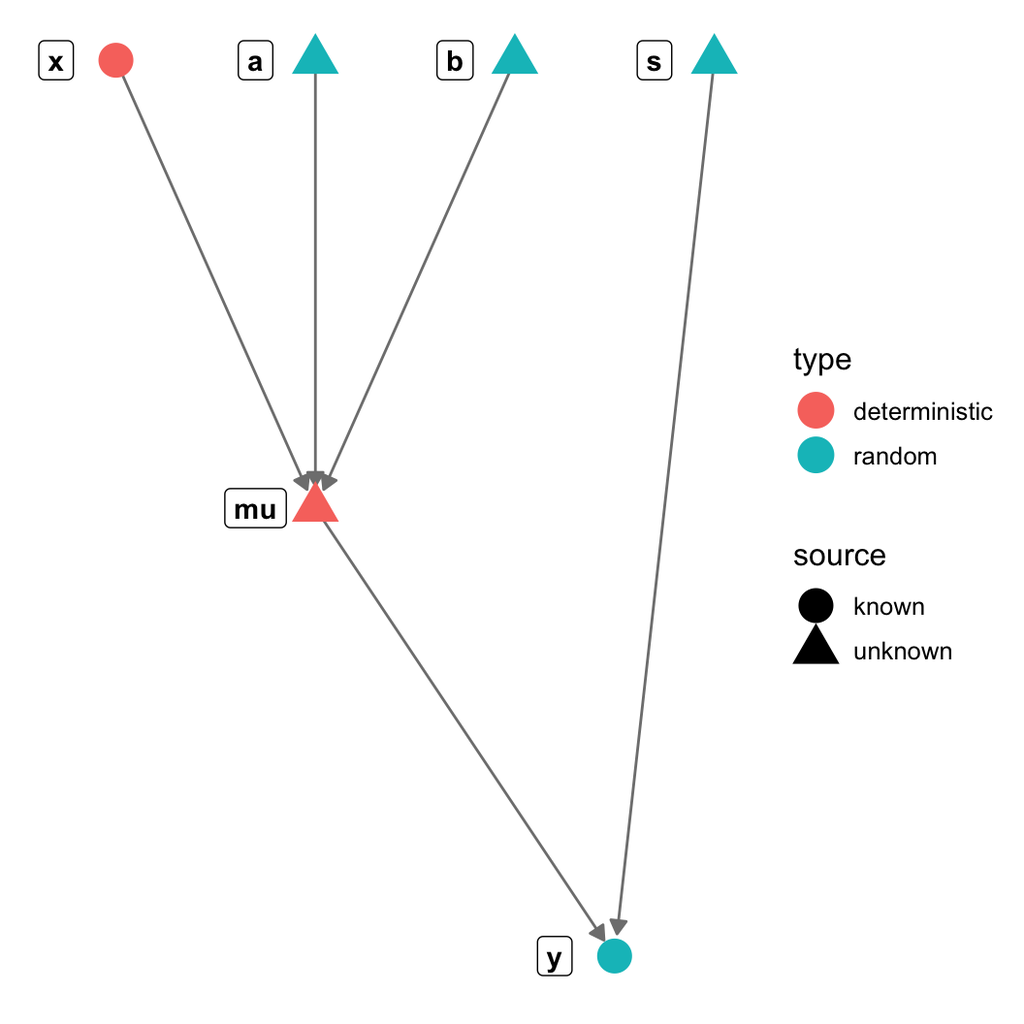

```stan
mu = a + b*x;
y ~ normal(mu, s);
a ~ normal(0, 20);
b ~ normal(0, 5);
s ~ exponential(0.2);
```

# Why Stan?

- For many models, faster than other MCMC samplers
- Fast convergence
- Very concise and natural model specification

# Writing models - data block

- Stan models come in blocks
- The `data` block tells Stan what to expect from all the data you will pass it
  - These are usually **knowns** in your model graph
  - Stan doesn’t how big a vector is when you pass it, so you have to tell it

```r
## R version
log_posterior = function(params, data) {
   y = data[['y']]
   x = data[['x']]
}
```

```stan
// Stan version
data {
   int n; // a single integer named n, number of data points
   vector [n] y; // a vector of n real numbers, named y
   vector [n] x;
}
```

# Writing models - parameters block

- The `parameters` block identifies **random unknowns**
  - specifying **constraints** allows us to avoid impossible values

```r
## R version
log_posterior = function(params, data) {
   y = data[['y']]
   x = data[['x']]
   a = params['a']
   b = params['b']
   s = params['s']

   if(s <= 0)
      return(-Inf)
}
```

```stan
// Stan version
data {
   int n; // a single integer named n, number of data points
   vector [n] y; // a vector of n real numbers, named y
   vector [n] x;
}
parameters {
   real a;
   real b;
   real <lower=0> s; // a single real number that must be positive
}
```

# Writing models - transformed parameters block

- Optionally, `transformed parameters` does what the name implies
  - Any variables declared in `data` or `parameters` can be used for transformations
  - For example, you can specify **deterministic unkowns** here

```r
## R version
log_posterior = function(params, data) {
   y = data[['y']]
   x = data[['x']]
   a = params['a']
   b = params['b']
   s = params['s']

   if(s <= 0)
      return(-Inf)

   mu = a + b * x
}
```

```stan
// Stan version
data {
   int n; // a single integer named n, number of data points
   vector [n] y; // a vector of n real numbers, named y
   vector [n] x;
}
parameters {
   real a;
   real b;
   real <lower=0> s; // a single real number that must be positive
}
transformed parameters {
    vector [n] mu = a * b * x;
    // or another example
    // vector [n] log_x = log(x);
}
```

# Writing models - model block

- The model block tells Stan how to evaluate the log posterior
  - Likelihood/prior distributions of **random variables** are specified with the `~` symbol

```r
## R version
log_posterior = function(params, data) {
   y = data[['y']]
   x = data[['x']]
   a = params['a']
   b = params['b']
   s = params['s']

   if(s <= 0)
      return(-Inf)

   mu = a + b * x
   log_lhood = sum(dnorm(y, mu, s, log = TRUE))
}
```

```stan
// Stan version
data {
   int n; // a single integer named n, number of data points
   vector [n] y; // a vector of n real numbers, named y
   vector [n] x;
}
parameters {
   real a;
   real b;
   real <lower=0> s; // a single real number that must be positive
}
transformed parameters {
    vector [n] mu = a * b * x;
}
model {
    y ~ normal(mu, s);
}
```

# Writing models - model block

- The model block tells Stan how to evaluate the log posterior
  - Likelihood/prior distributions of **random variables** are specified with the `~` symbol

```r
## R version
log_posterior = function(params, data) {
   y = data[['y']]
   x = data[['x']]
   a = params['a']
   b = params['b']
   s = params['s']

   if(s <= 0)
      return(-Inf)

   mu = a + b * x
   log_lhood = sum(dnorm(y, mu, s, log = TRUE))
   log_prior = dnorm(a, 0, 10, log=TRUE) +
        dnorm(B, 0, 5, log=TRUE) +
        dexp(s, 0.1, log=TRUE)
   return(log_lhood + log_prior)
}
```

```stan
// Stan version
data {
   int n; // a single integer named n, number of data points
   vector [n] y; // a vector of n real numbers, named y
   vector [n] x;
}
parameters {
   real a;
   real b;
   real <lower=0> s; // a single real number that must be positive
}
transformed parameters {
    vector [n] mu = a * b * x;
}
model {
    y ~ normal(mu, s);
    a ~ normal(0, 10);
    b ~ normal(0, 5);
    s ~ exponential(0.1);
}
```

Save this code to a file. For example: `stan/sample_stan_lm.stan`

# Fitting models

- Save your Stan code in a .stan file
- Compile your model using the `stan_model` function
- Take samples using the `sampling` function

```r
## R version
# get the data and format it
library(data.table)
Howell1 = fread("https://github.com/rmcelreath/rethinking/raw/master/data/Howell1.csv")
mh_data = list(
    y = Howell1$height
    x = Howell1$weight
)
# load the metropolis sampler from this course
source("r/mh.r")

# take 10000 samples, with adaptation
samples = metropolis(log_posterior, initial = c(a = 0, b = 0, s = 1),
                     data = mh_data)
```

```r
## rstan version
library(rstan)
library(data.table)

# get the data and format it for rstan
Howell1 = fread("https://github.com/rmcelreath/rethinking/raw/master/data/Howell1.csv")
stan_data = list(
    y = Howell1$height,
    x = Howell1$weight,
    n = length(Howell1$weight)
)
# compile the model
model = stan_model(file = "stan/sample_stan_lm.stan")

# take 5000 samples
samples = sampling(model, iter=5000, data = standata)
```

# Variables in Stan

- Stan variables have a strong, fixed type that must be declared
- Variables can have **constraints**

**Scalar types**

- `int`
- `real`

```stan
int my_int;
real my_real;
real <lower=0> my_positive_real;
real <lower=0, upper=1> my_proportion;
```

# Variables in Stan - containers

### Vectors

- 1-dimension
- real numbers only

`vector <constraint> [length] name`

```stan
vector [10] my_ten_reals;
vector <lower=0> [n] n_positive_numbers;
```

# Variables in Stan - containers

### Vectors

- 1-dimension
- real numbers only

`vector <constraint> [length] name`

### Matrices

- 2-dimensions
- real numbers only

`matrix <constraint> [rows, columns] name`

```stan
vector [10] my_ten_reals;
vector <lower=0> [n] n_positive_numbers;
matrix [n,k] my_matrix;
```

# Variables in Stan - containers

### Vectors

- 1-dimension
- real numbers only

`vector <constraint> [length] name`

### Matrices

- 2-dimensions
- real numbers only

`matrix <constraint> [rows, columns] name`

### Arrays

- any dimensions
- any type (even other containers)

`type <constraint> name [dimensions]`

```stan
vector [10] my_ten_reals;
vector <lower=0> [n] n_positive_numbers;
matrix [n,k] my_matrix;
int ten_integers [10]; // array of ints
real ten_reals [10]; // array of reals
vector <lower=0> [10] array_of_vectors [5]; // 5 vectors, each of length 10
```

# German Tank problem in Stan

2. Recall the German tank problem presented in lecture. Use the following captured serial numbers:

`s = c(147, 126, 183, 88, 9, 203, 16, 10, 112, 205)`

- We decided that tank serial numbers are **uniformly distributed** with a minimum of 1 and a maximum possible value equal to $N_{max}$
- We want to estimate $N_{max}$ from the data
- Here we use a very vague prior for $N_{max}$

$$\begin{aligned}
s & \sim \mathrm{U}(1, N_{max}) \\
N_{max} & \sim \mathrm{Gamma}(\alpha=0.001, \beta=0.001)
\end{aligned}$$

# German Tank problem: Stan model

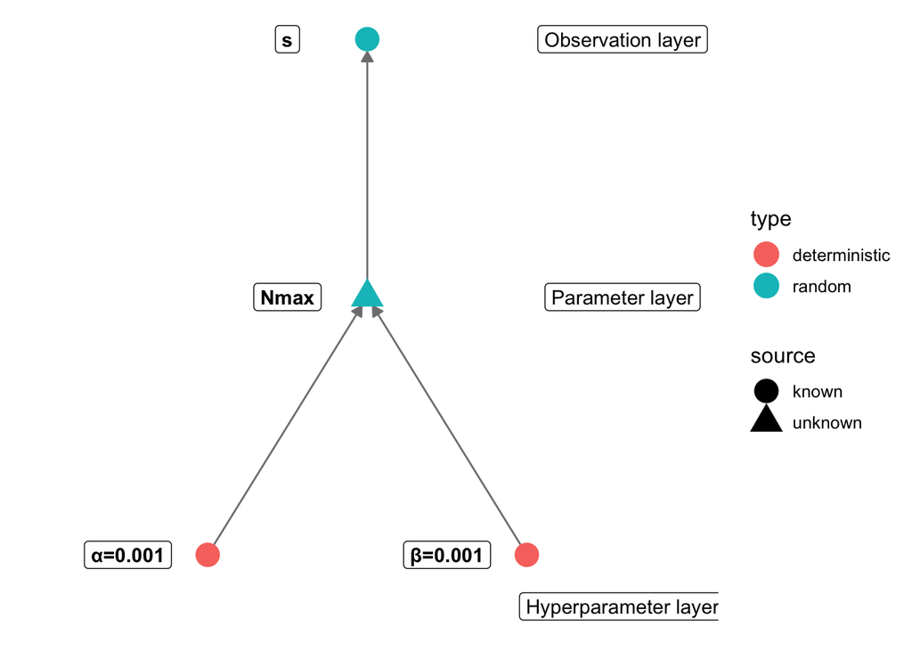

```stan
data {
   int <lower = 1> n; // number of data points
   vector <lower=1> [n] s; // captured serial numbers
}
parameters {
   real <lower = max(s)> Nmax;
}
model {
   s ~ uniform(1, Nmax); // likelihood
   // this is a super vague prior!
   Nmax ~ gamma(0.001, 0.001);
}
```

```r
library(rstan)
 # the code above is saved in stan/tanks.stan
tanks_mod = stan_model("stan/tanks.stan")
```

# German Tank problem: MAP estimate

- Sometimes we are only interested in the posterior mode (i.e., the MAP)
- Can use `rstan::optimizing` to get this

```r
s = c(147, 126, 183, 88, 9, 203, 16, 10, 112, 205)
standat = list(n = length(s), s = s)
fit_map = optimizing(tanks_mod, data = standat)
fit_map$par
## Nmax
##  205
```

As before, the MAP is identical to `max(s)`, but many other values are possible!

# German Tank problem: Sampling

- It’s clear we can learn a lot more from the entire posterior!
- The `bayesplot` package is great for visualising output from `stan`, `metropolis`, and many other Bayesian packages.

```r
# parameter explanations:
#   iter: how many iterations (you will get iter/2 samples)
#   chains: how many parallel MCMC chains?
#   refresh: if 0, stan won't show you a progress bar (nice for rmd files)
fit = sampling(tanks_mod, data = standat, iter = 5000, chains = 1, refresh = 0)
samples = as.matrix(fit)
head(samples)
```

```
##           parameters
## iterations     Nmax      lp__
##       [1,] 226.1407 -56.75793
##       [2,] 226.1407 -56.75793
##       [3,] 211.6211 -57.17141
##       [4,] 206.6496 -58.29355
##       [5,] 206.9084 -58.16191
##       [6,] 205.5159 -59.39410
```

```r
source("../r/metrop.r") ## for HDPI
rbind(hdpi = hpdi(samples[,1]),
      quantile = quantile(samples[,1], c(0.05, 0.95)))
```

```
##                5%      95%
## hdpi     205.0023 260.3608
## quantile 205.8477 279.2651
```

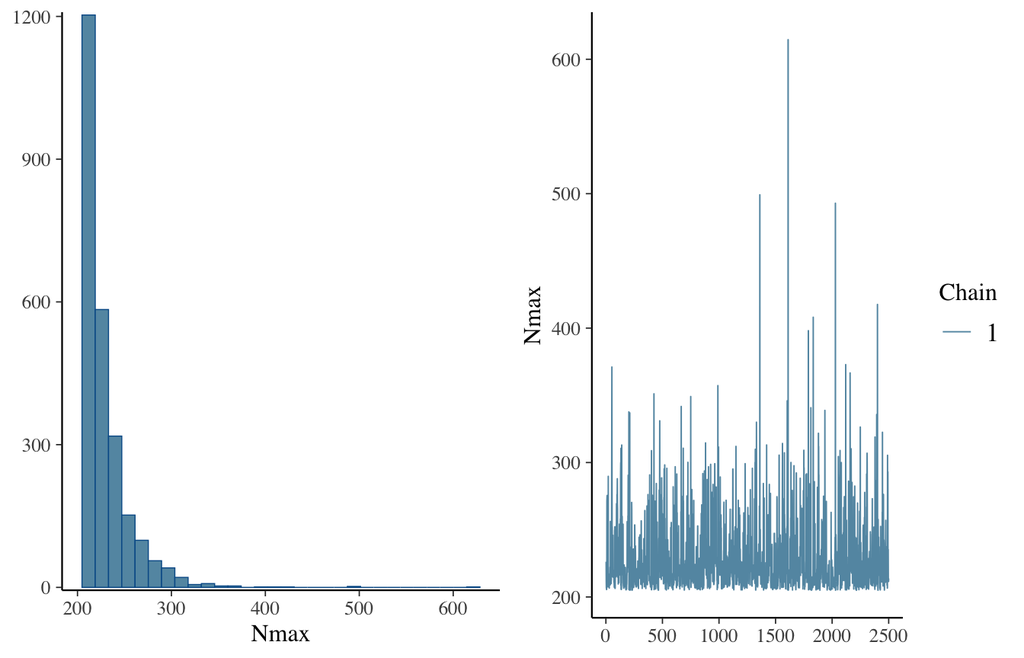

```r
library(bayesplot)
mcmc_combo(samples, c("hist", "trace"), pars = "Nmax")
```

# More linear models

- Our linear model used a single x-variable: $\mathbb{E}(y) = a + bx$
- It is trivial to add additional predictors to a model: $\mathbb{E}(y) = a + b_1x_1 + b_2x_2 + \dots + b_nx_n$

# More linear models

- Our linear model used a single x-variable: $\mathbb{E}(y) = a + bx$
- It is trivial to add additional predictors to a model: $\mathbb{E}(y) = a + b_1x_1 + b_2x_2 + \dots + b_nx_n$
- You can also easily add a “curve” in the relationship between x and y by transforming x:

$$\mathbb{E}(y) = a + b_1x + b_2x^2$$

- Use caution: curves can predict silly things
  - does it make sense that height decreases after a certain weight?
- This is still a linear model: $\mathbb{E}(y)$ is linear with respect to transformations of x

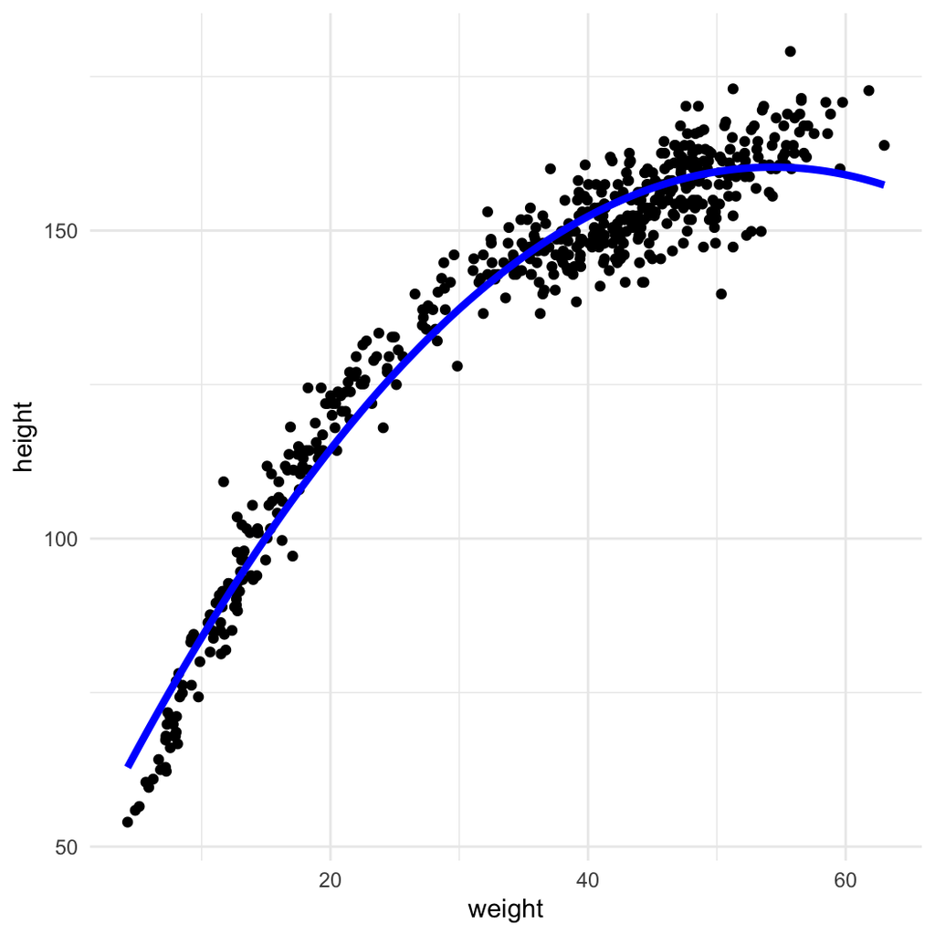

# Categorical Variables

- Perhaps we want to model a categorical variable based on age.

```r
Howell1$age_group = cut(Howell1$age, breaks = c(-1, 12, 22, 200),
                        labels = c("child", "young", "adult"))
Howell1
```

```
##       height    weight age male age_group
##   1: 151.765 47.825606  63    1     adult
##   2: 139.700 36.485806  63    0     adult
##   3: 136.525 31.864838  65    0     adult
##   4: 156.845 53.041914  41    1     adult
##   5: 145.415 41.276872  51    0     adult
##  ---
## 540: 145.415 31.127751  17    1     young
## 541: 162.560 52.163080  31    1     adult
## 542: 156.210 54.062496  21    0     young
## 543:  71.120  8.051258   0    1     child
## 544: 158.750 52.531623  68    1     adult
```

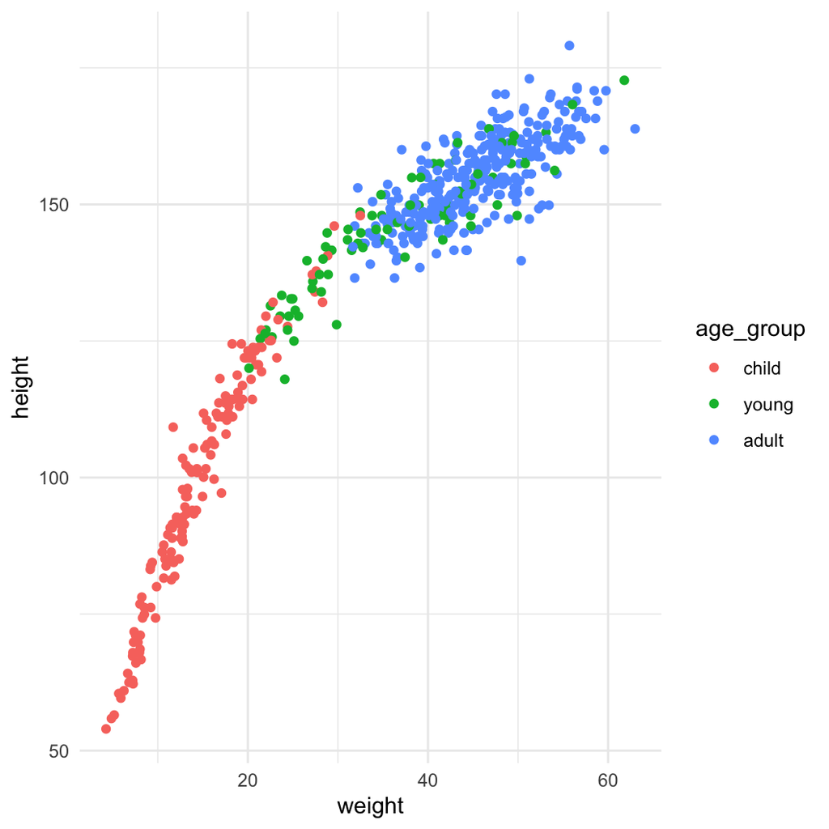

# Categorical Variables

- Perhaps we want to model a categorical variable based on age.
- `lm` and other tools often handle this automatically.
- We can reproduce this in stan (and in custom models in R) with one of 2 methods:
  - dummy variables
  - indexing (will be shown later)
- We can represent a categorical variable with $k$ levels using $k-1$ binary (0 or 1) variables

```r
Howell1$is_child = ifelse(Howell1$age_group == "child", 1, 0)
Howell1$is_young = ifelse(Howell1$age_group == "young", 1, 0)
Howell1
```

```
##       height    weight age male age_group is_child is_young
##   1: 151.765 47.825606  63    1     adult        0        0
##   2: 139.700 36.485806  63    0     adult        0        0
##   3: 136.525 31.864838  65    0     adult        0        0
##   4: 156.845 53.041914  41    1     adult        0        0
##   5: 145.415 41.276872  51    0     adult        0        0
##  ---
## 540: 145.415 31.127751  17    1     young        0        1
## 541: 162.560 52.163080  31    1     adult        0        0
## 542: 156.210 54.062496  21    0     young        0        1
## 543:  71.120  8.051258   0    1     child        1        0
## 544: 158.750 52.531623  68    1     adult        0        0
```

# Categorical Variables

- Our categorical variable might represent a different **mean** for each group
  - Model this by adding something to the model intercept

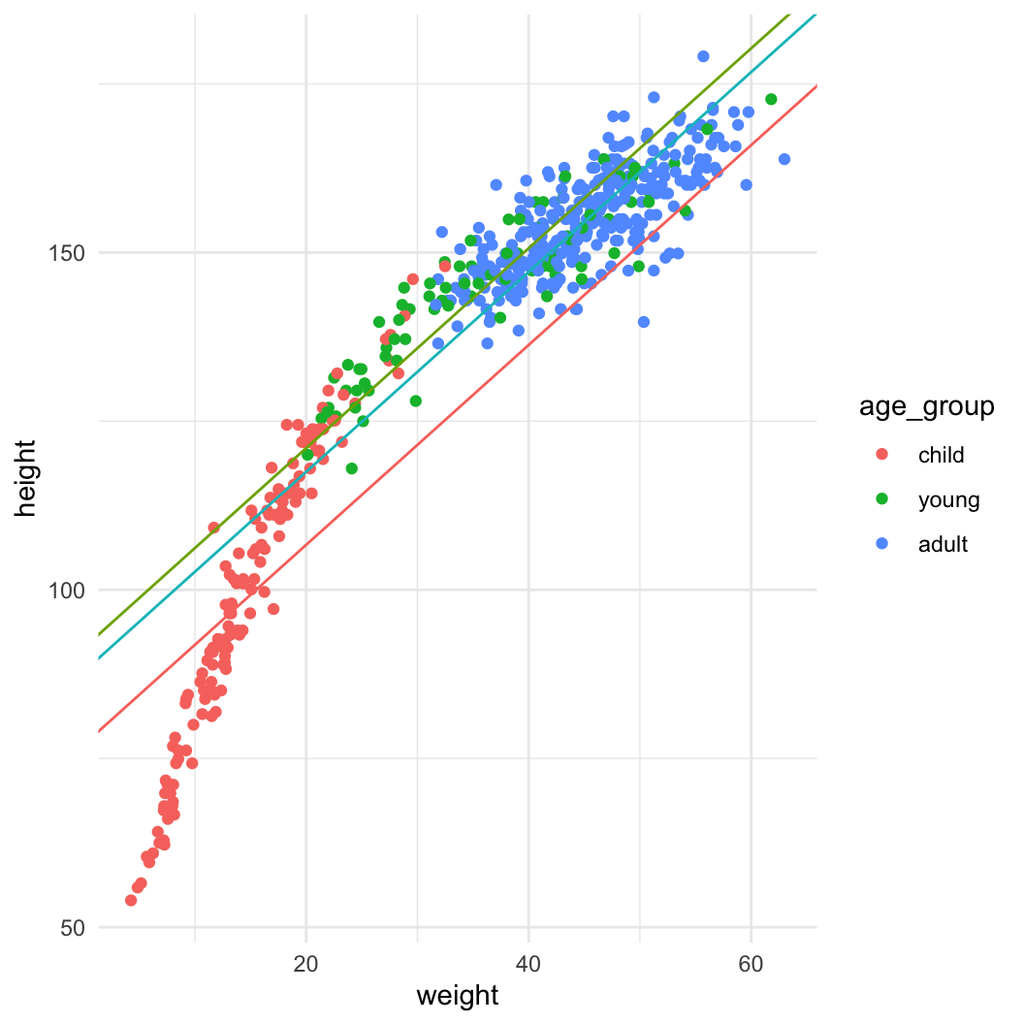

```stan
data {
   int n;
   vector [n] height;
   vector [n] weight;
   vector  <lower = 0, upper = 1> [n] is_child;
   vector  <lower = 0, upper = 1> [n] is_young;
}
parameters {
   real a; // default slope (for adults)
   real a_child; // additional effect of being a child
   real a_young; // additional effect of being young
   real b;
   real <lower=0> s;
}
transformed parameters {
    vector [n] intercept = a + a_child * is_child + a_young * is_young;
    vector [n] mu = intercept + b * x;
}
model {
    y ~ normal(mu, s);
    a ~ normal(0, 10);
    a_child ~ normal(0, 10);
    a_young ~ normal(0, 10);
    b ~ normal(0, 5);
    s ~ exponential(0.1);
}
```

# Categorical Variables

- Our categorical variable might represent a different **mean** for each group
  - Model this by adding something to the model intercept
- Or we might represent a different **rate of change** for each group (e.g., children grow more quickly)
  - Modelled by adding something to the slope term
  - Can also think of this as an **interaction** between a categorical and continuous variable

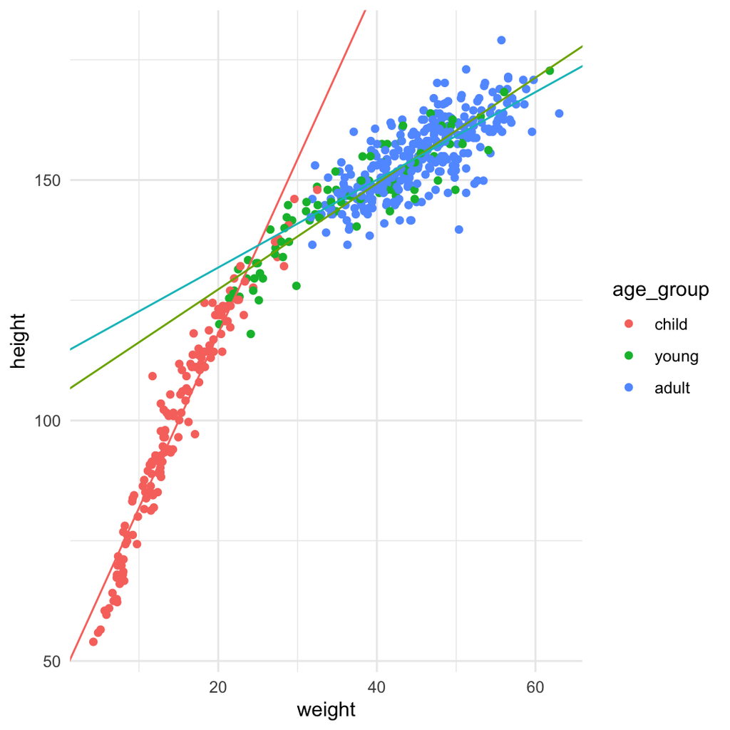

```stan
data {
   int n;
   vector [n] height;
   vector [n] weight;
   vector  <lower = 0, upper = 1> [n]is_child;
   vector  <lower = 0, upper = 1> [n] is_young;
}
parameters {
   real a; // default slope (for adults)
   real a_child; // additional effect of being a child
   real a_young; // additional effect of being young
   real b;
   real b_child; // additional slope effect of being a child
   real b_young; // additional slope effect of being young
   real <lower=0> s;
}
transformed parameters {
    vector [n] intercept = a + a_child * is_child + a_young * is_young;
    vector [n] slope = b + b_child * is_child + b_young * is_young;
    vector [n] mu = intercept + slope * x;
}
model {
    y ~ normal(mu, s);
    a ~ normal(0, 10);
    a_child ~ normal(0, 10);
    a_young ~ normal(0, 10);
    b ~ normal(0, 5);
    b_child ~ normal(0, 5);
    b_young ~ normal(0, 5);
    s ~ exponential(0.1);
}
```

# Bayesian Analysis Workflow